# Class_Practice

Tanu

2/11/2020

## R Markdown Demonstration using Breast Imaging Data

Data Citation: This breast cancer database was obtained from the University of Wisconsin Hospitals, Madison from Dr. William H. Wolberg. See Machine learning techniques to diagnose breast cancer from image-processed nuclear features of fine needle aspirates. Cancer Letters 1994; 77:163-171.

### Step 1: Load Packages

We will be using two packages in addition to base R. Amelia is for missing data and will provide us with a plot of missingness. Caret is primarly from classification and regression trees, but has many features that are useful for data preprocessing. We will be using a function to partition data into training and testing.

```r
#install.packages("caret")

library(Amelia)
library(caret)
```

### Step 2: Load Data into R Environment and Perform Data Cleaning

#### Illustrates the following:

1. How to load a flat text file
2. How to assign column names when none are provided
3. How to check variable types across the dataframe
4. How to recode missing indicators, change variable types and explore variable distributions
5. Create a quick plot to indicate missingness
6. Create a quick and dirty plot to compare features across outcome levels

```r
bc.data<-read.csv("Data/breast-cancer-wisconsin.data.txt", header=FALSE)

var.names<-c("id", "clump_thickness", "uniformity_csize", "uniformity_cshape", "marg_adhesion", "single_ecell_size", "bare_nuclei", "b_chromatin", "normal_nucleoli", "mitoses", "outcome")

colnames(bc.data)<-var.names
str(bc.data)
```

```
## 'data.frame':    699 obs. of  11 variables:
##  $ id               : int  1000025 1002945 1015425 1016277 1017023 1017122 1018099 1018561 1033078 1033078 ...
##  $ clump_thickness  : int  5 5 3 6 4 8 1 2 2 4 ...
##  $ uniformity_csize : int  1 4 1 8 1 10 1 1 1 2 ...
##  $ uniformity_cshape: int  1 4 1 8 1 10 1 2 1 1 ...
##  $ marg_adhesion    : int  1 5 1 1 3 8 1 1 1 1 ...
##  $ single_ecell_size: int  2 7 2 3 2 7 2 2 2 2 ...
##  $ bare_nuclei      : Factor w/ 11 levels "?","1","10","2",..: 2 3 4 6 2 3 3 2 2 2 ...
##  $ b_chromatin      : int  3 3 3 3 3 9 3 3 1 2 ...
##  $ normal_nucleoli  : int  1 2 1 7 1 7 1 1 1 1 ...
##  $ mitoses          : int  1 1 1 1 1 1 1 1 5 1 ...
##  $ outcome          : int  2 2 2 2 2 4 2 2 2 2 ...
```

```r
bc.data[bc.data=="?"]<-NA
bc.data$bare_nuclei<-as.numeric(bc.data$bare_nuclei)

bc.data$outcome<-as.factor(bc.data$outcome)
levels(bc.data$outcome)<-c("Benign", "Malignant")
str(bc.data)
```

```
## 'data.frame':    699 obs. of  11 variables:
##  $ id               : int  1000025 1002945 1015425 1016277 1017023 1017122 1018099 1018561 1033078 1033078 ...
##  $ clump_thickness  : int  5 5 3 6 4 8 1 2 2 4 ...
##  $ uniformity_csize : int  1 4 1 8 1 10 1 1 1 2 ...
##  $ uniformity_cshape: int  1 4 1 8 1 10 1 2 1 1 ...
##  $ marg_adhesion    : int  1 5 1 1 3 8 1 1 1 1 ...
##  $ single_ecell_size: int  2 7 2 3 2 7 2 2 2 2 ...
##  $ bare_nuclei      : num  2 3 4 6 2 3 3 2 2 2 ...
##  $ b_chromatin      : int  3 3 3 3 3 9 3 3 1 2 ...
##  $ normal_nucleoli  : int  1 2 1 7 1 7 1 1 1 1 ...
##  $ mitoses          : int  1 1 1 1 1 1 1 1 5 1 ...
##  $ outcome          : Factor w/ 2 levels "Benign","Malignant": 1 1 1 1 1 2 1 1 1 1 ...
```

```r
summary(bc.data)
```

```
##        id           clump_thickness  uniformity_csize uniformity_cshape
##  Min.   :   61634   Min.   : 1.000   Min.   : 1.000   Min.   : 1.000
##  1st Qu.:  870688   1st Qu.: 2.000   1st Qu.: 1.000   1st Qu.: 1.000
##  Median : 1171710   Median : 4.000   Median : 1.000   Median : 1.000
##  Mean   : 1071704   Mean   : 4.418   Mean   : 3.134   Mean   : 3.207
##  3rd Qu.: 1238298   3rd Qu.: 6.000   3rd Qu.: 5.000   3rd Qu.: 5.000
##  Max.   :13454352   Max.   :10.000   Max.   :10.000   Max.   :10.000
##
##  marg_adhesion    single_ecell_size  bare_nuclei      b_chromatin
##  Min.   : 1.000   Min.   : 1.000    Min.   : 2.000   Min.   : 1.000
##  1st Qu.: 1.000   1st Qu.: 2.000    1st Qu.: 2.000   1st Qu.: 2.000
##  Median : 1.000   Median : 2.000    Median : 2.000   Median : 3.000
##  Mean   : 2.807   Mean   : 3.216    Mean   : 3.217   Mean   : 3.438
##  3rd Qu.: 4.000   3rd Qu.: 4.000    3rd Qu.: 3.000   3rd Qu.: 5.000
##  Max.   :10.000   Max.   :10.000    Max.   :11.000   Max.   :10.000
##                                     NA's   :16
##  normal_nucleoli     mitoses            outcome
##  Min.   : 1.000   Min.   : 1.000   Benign   :458
##  1st Qu.: 1.000   1st Qu.: 1.000   Malignant:241
##  Median : 1.000   Median : 1.000
##  Mean   : 2.867   Mean   : 1.589
##  3rd Qu.: 4.000   3rd Qu.: 1.000
##  Max.   :10.000   Max.   :10.000
##
```

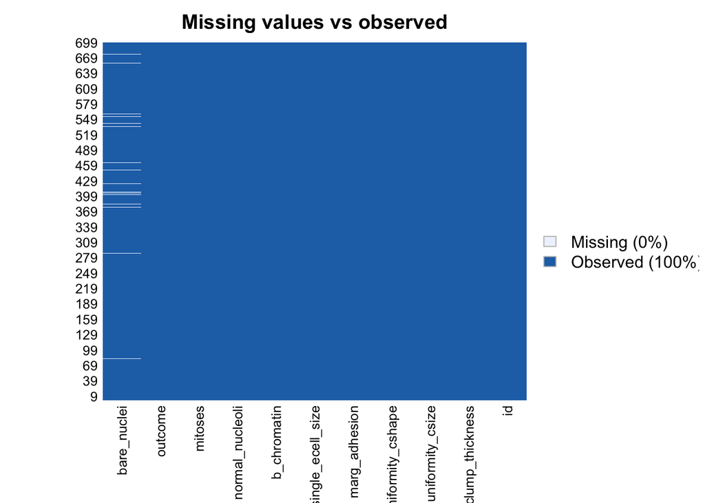

```r
missmap(bc.data, main = "Missing values vs observed")
```

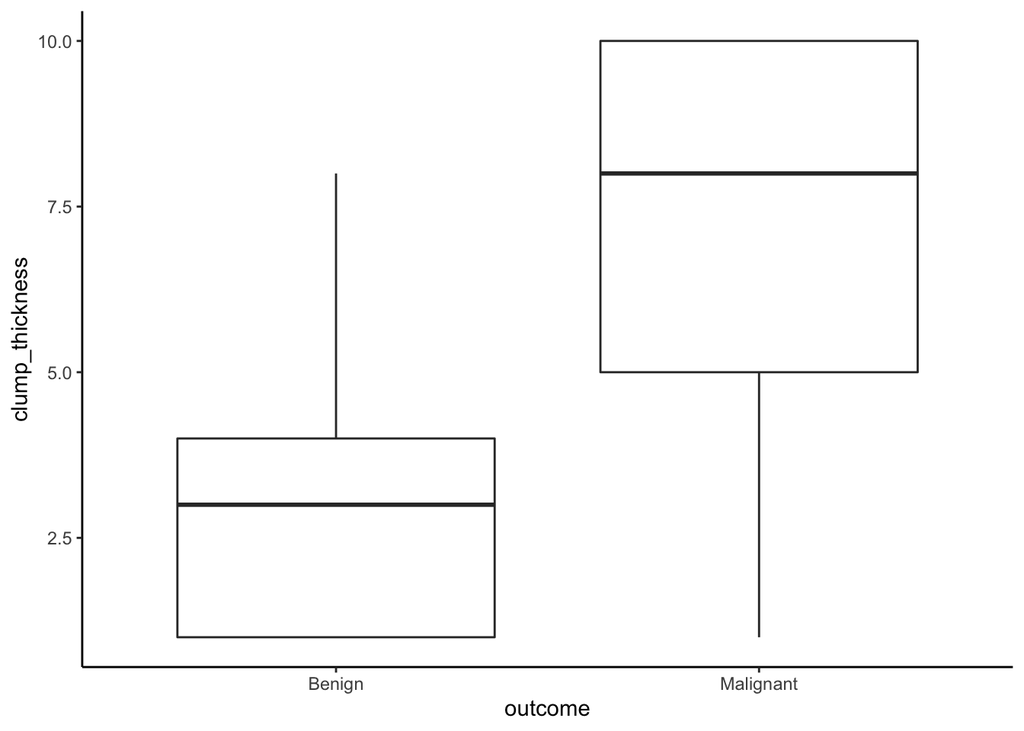

```r
ggplot(bc.data, aes(y=clump_thickness, x=outcome)) +
  geom_boxplot()+theme_classic()
```

### Step 3: Partition data into training and testing sets

Many ways to do this. Using CreateDataPartition in caret package. Allows you to specify factor outcome so proportion with outcome is similar in training and testing dataset. We are specifying a 70/30 split training/testing. Remember to set seed so that the results are reproducible.

```r
set.seed(100)
train.indices<-createDataPartition(y=bc.data$outcome,p=0.7,list=FALSE)

training<-bc.data[train.indices,]
testing<-bc.data[-train.indices,]
```

### Step 4: Construct logistic regression models to predict Malignancy

- Model 1: Include all features
- Model 2: Include only clump thickness

```r
model.1 <- glm(outcome ~ . ,family=binomial(link='logit'),data=training)
summary(model.1)
```

```
##
## Call:
## glm(formula = outcome ~ ., family = binomial(link = "logit"),
##     data = training)
##
## Deviance Residuals:
##     Min       1Q   Median       3Q      Max
## -3.5476  -0.1169  -0.0561   0.0168   2.1231
##
## Coefficients:
##                     Estimate Std. Error z value Pr(>|z|)
## (Intercept)       -1.080e+01  1.905e+00  -5.669 1.43e-08 ***
## id                -1.913e-07  1.020e-06  -0.187  0.85130
## clump_thickness    5.876e-01  1.424e-01   4.126 3.69e-05 ***
## uniformity_csize   1.598e-02  2.296e-01   0.070  0.94451
## uniformity_cshape  4.785e-01  2.546e-01   1.880  0.06016 .
## marg_adhesion      4.066e-01  1.266e-01   3.211  0.00132 **
## single_ecell_size  1.450e-01  1.646e-01   0.880  0.37861
## bare_nuclei        1.342e-01  1.120e-01   1.199  0.23062
## b_chromatin        4.902e-01  1.816e-01   2.699  0.00695 **
## normal_nucleoli    2.115e-01  1.189e-01   1.779  0.07532 .
## mitoses            8.510e-01  3.296e-01   2.582  0.00982 **
## ---
## Signif. codes:  0 '***' 0.001 '**' 0.01 '*' 0.05 '.' 0.1 ' ' 1
##
## (Dispersion parameter for binomial family taken to be 1)
##
##     Null deviance: 618.587  on 477  degrees of freedom
## Residual deviance:  88.679  on 467  degrees of freedom
##   (12 observations deleted due to missingness)
## AIC: 110.68
##
## Number of Fisher Scoring iterations: 8
```

```r
model.2<-glm(outcome ~ clump_thickness, family=binomial(link='logit'), data=training)
summary(model.2)
```

```
##
## Call:
## glm(formula = outcome ~ clump_thickness, family = binomial(link = "logit"),
##     data = training)
##
## Deviance Residuals:
##     Min       1Q   Median       3Q      Max
## -2.2485  -0.6146  -0.1427   0.1522   2.6856
##
## Coefficients:
##                 Estimate Std. Error z value Pr(>|z|)
## (Intercept)     -5.58624    0.49594  -11.26   <2e-16 ***
## clump_thickness  1.00385    0.09595   10.46   <2e-16 ***
## ---
## Signif. codes:  0 '***' 0.001 '**' 0.01 '*' 0.05 '.' 0.1 ' ' 1
##
## (Dispersion parameter for binomial family taken to be 1)
##
##     Null deviance: 631.35  on 489  degrees of freedom
## Residual deviance: 307.05  on 488  degrees of freedom
## AIC: 311.05
##
## Number of Fisher Scoring iterations: 6
```

```r
OR<-exp(model.2$coefficients[2])
```

### Step 5: Compare accuracy of two different models in test set

This is a simple evaluation . We are obtaining predicted probabilities for test set using the model built on the training set and rounding to 0/1 for classification to benign (0) or malignant (1). We are testing both of our models in the test set. Typically, these types of comparisons are done using cross-validation within the training set. That will be covered in Module 2. There is also code for generating calibration curves, which will be discussed in more detail in Module 2.

```r
fitted.results <- predict(model.1,testing,type='response')
fitted.results.p <- ifelse(fitted.results > 0.5,1,0)

testing.outcome<-(as.numeric(testing$outcome)-1)

misClasificError <- mean(fitted.results.p != testing.outcome, na.rm=T)
print(paste('Accuracy Model 1',1-misClasificError))
```

```
## [1] "Accuracy Model 1 0.965853658536585"
```

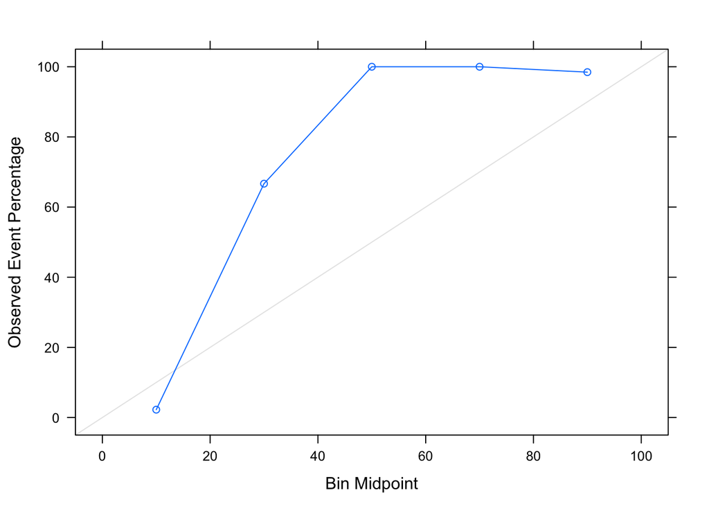

```r
testProbs <- data.frame(obs = testing$outcome,
                        pred.logit=fitted.results)

calPlotData<-calibration(obs ~ pred.logit, data = testProbs, class="Malignant", cuts=5)

xyplot(calPlotData, auto.key = list(columns = 2))
```

```r
fitted.results.rmodel <- predict(model.2,testing,type='response')
fitted.results.rmodel.p <- ifelse(fitted.results.rmodel > 0.5,1,0)

misClasificError <- mean(fitted.results.rmodel.p != testing.outcome, na.rm=T)
print(paste('Accuracy Model 2',1-misClasificError))
```

```
## [1] "Accuracy Model 2 0.842105263157895"
```

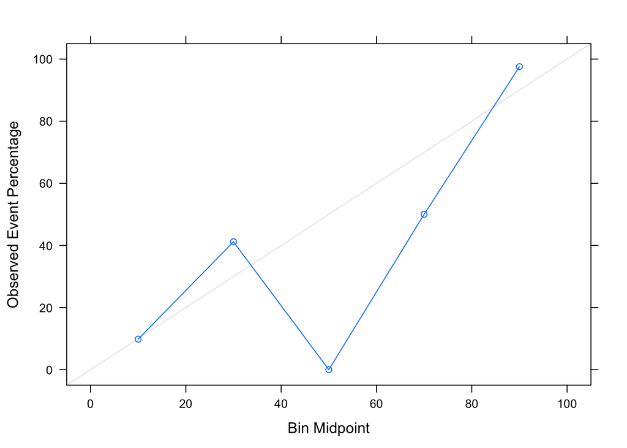

```r
testProbs.rmodel <- data.frame(obs = testing$outcome,
                        pred.logit.rmodel=fitted.results.rmodel)

calPlotData.rmodel<-calibration(obs ~ pred.logit.rmodel, data = testProbs.rmodel, class="Malignant", cuts=5)

xyplot(calPlotData.rmodel, auto.key = list(columns = 2))
```